# Jeevansathi.com Exploratory Text analysis

20/10/2020

Using the “Profile Description” variable, here is a basic exploratory analysis of user profiles on Jeevansathi.com. We have a total of about 577,000 profiles in our dataset (September Scrape).

### Frequency Table (Normalised)

The following frequency table is normalised by the number of profiles for each category (Male, Female and Overall).  
Common English Stopwords (is, an, the etc. ) have been removed and some other stopwords have been added to the negative list.  
Here is a list of them : (can be ignored while reading)

```
##   [1] "Stopwords : " "family"       "girl"         "partner"      "like"
##   [6] "m"            "im"           "work"         "new"          "working"
##  [11] "person"       "also"         "well"         "name"         "can"
##  [16] "currently"    "completed"    "daughter"     "looking"      "good"
##  [21] "believe"      "hidden"       "profile"      "living"       "Want"
##  [26] "son"          "brother"      "sister"       "s"            "time"
##  [31] "done"         "hi"           "live"         "one"          "life"
##  [36] "n"            "delhi"        "mumbai"       "hai"          "ki"
##  [41] "hu"           "belong"       "towards"      "aur"          "someone"
##  [46] "people"       "always"       "go"           "thing"        "t"
##  [51] "se"           "ek"           "ho"           "mai"          "jo"
##  [56] "ka"           "guy"          "go"           "give"         "mujhe"
##  [61] "get"          "pune"         "hi"           "hello"        "now"
##  [66] "believe"      "make"         "now"          "take"         "like"
##  [71] "need"         "base"         "search"       "go"           "high"
```

[output cut: 30 more lines]

We also lemmatize the text by bringing words to their roots. For example, loving, lover and love turn into love.

Once that is done, we generate 1-grams, 2-grams and 3-grams (collection of 1,2 and 3 word phrases) and calculate their percentage frequency.

## 1-gram

Percentage Frequency of words in 576903 profiles on Jeevansathi.com (top 100)

|  | Overall 576903 profiles |
| --- | --- |
| love | 39.39% |
| simple | 23.66% |
| care | 20.78% |
| value | 18.08% |
| travel | 15.06% |
| understand | 10.87% |
| respect | 10.83% |
| class | 8.53% |
| friend | 8.47% |
| music | 8.42% |
| fun | 8.31% |
| engineer | 7.90% |
| middle | 7.71% |
| mind | 7.50% |
| educate | 7.47% |
| father | 7.43% |
| nature | 7.37% |
| read | 7.13% |
| cook | 6.96% |
| job | 6.95% |
| interest | 6.89% |
| place | 6.83% |
| modern | 6.73% |
| enjoy | 6.66% |
| hobby | 6.59% |
| business | 6.57% |
| mother | 6.49% |
| movie | 6.39% |
| professional | 6.31% |
| earth | 6.24% |

[output cut: 70 more lines]

|  | Male 307779 profiles |
| --- | --- |
| love | 35.97% |
| simple | 23.31% |
| care | 18.68% |
| value | 14.66% |
| travel | 14.63% |
| engineer | 9.87% |
| understand | 9.35% |
| respect | 9.28% |
| business | 9.23% |
| friend | 9.03% |
| class | 8.69% |
| fun | 8.17% |
| middle | 7.94% |
| father | 7.63% |
| music | 7.60% |
| mind | 7.48% |
| movie | 7.11% |
| job | 6.91% |
| enjoy | 6.81% |
| place | 6.80% |
| mother | 6.72% |
| company | 6.55% |
| watch | 6.51% |
| interest | 6.49% |
| nature | 6.41% |
| professional | 6.18% |
| hobby | 6.16% |
| educate | 5.80% |
| earth | 5.78% |
| play | 5.72% |

[output cut: 70 more lines]

|  | Female 269124 profiles |
| --- | --- |
| love | 43.31% |
| simple | 24.06% |
| care | 23.19% |
| value | 21.99% |
| travel | 15.56% |
| understand | 12.62% |
| respect | 12.59% |
| cook | 11.09% |
| educate | 9.38% |
| music | 9.36% |
| read | 8.97% |
| modern | 8.55% |
| nature | 8.48% |
| fun | 8.47% |
| class | 8.35% |
| friend | 7.83% |
| mind | 7.51% |
| middle | 7.44% |
| interest | 7.35% |
| father | 7.19% |
| hobby | 7.08% |
| job | 6.99% |
| settle | 6.95% |
| place | 6.85% |
| traditional | 6.83% |
| university | 6.83% |
| earth | 6.77% |
| enjoy | 6.49% |
| professional | 6.46% |
| listen | 6.41% |

[output cut: 70 more lines]

## 2-gram

Percentage Frequency of 2 word phrases in 576903 profiles on Jeevansathi.com (top 50)

|  | Overall 576903 profiles |
| --- | --- |
| middle class | 7.33% |
| fun love | 6.80% |
| love travel | 4.94% |
| open mind | 4.69% |
| listen music | 3.58% |
| love care | 3.52% |
| watch movie | 3.38% |
| explore place | 2.96% |
| positive attitude | 2.84% |
| respect elder | 2.61% |
| moral value | 2.61% |
| care love | 2.60% |
| upper middle | 2.42% |
| traditional value | 2.14% |
| read book | 1.97% |
| love cook | 1.82% |
| private sector | 1.79% |
| dependable care | 1.75% |
| value respect | 1.63% |
| soft speak | 1.63% |
| travel explore | 1.59% |
| class nuclear | 1.59% |
| kind hearted | 1.57% |
| software engineer | 1.50% |
| modern traditional | 1.41% |
| career orient | 1.31% |
| modern thinker | 1.27% |
| moderate value | 1.20% |
| music watch | 1.17% |
| father retire | 1.16% |
| warm care | 1.12% |
| straight forward | 1.12% |
| love explore | 1.11% |
| simple care | 1.07% |
| bachelor degree | 1.06% |
| thinker value | 1.05% |
| master degree | 1.04% |
| care understand | 1.03% |
| simple earth | 1.00% |
| simple love | 0.98% |
| god fear | 0.97% |
| broad mind | 0.92% |
| software professional | 0.92% |
| honest care | 0.91% |
| love love | 0.89% |
| hobby include | 0.89% |
| value ancestor | 0.88% |
| computer science | 0.87% |
| sense humour | 0.87% |
| religious moral | 0.87% |

|  | Male 307779 profiles |
| --- | --- |
| middle class | 7.54% |
| fun love | 6.31% |
| love travel | 4.75% |
| open mind | 4.37% |
| watch movie | 3.44% |
| listen music | 2.85% |
| positive attitude | 2.80% |
| explore place | 2.70% |
| upper middle | 2.63% |
| love care | 2.47% |
| moral value | 2.37% |
| care love | 2.23% |
| respect elder | 2.22% |
| dependable care | 2.09% |
| private sector | 1.89% |
| traditional value | 1.82% |
| software engineer | 1.78% |
| class nuclear | 1.72% |
| value respect | 1.53% |
| read book | 1.52% |
| play cricket | 1.51% |
| travel explore | 1.44% |
| kind hearted | 1.38% |
| modern thinker | 1.30% |
| music watch | 1.25% |
| moderate value | 1.20% |
| broad mind | 1.20% |
| orient dependable | 1.18% |
| bachelor degree | 1.16% |
| father retire | 1.12% |
| warm care | 1.11% |
| thinker value | 1.09% |
| software professional | 1.08% |
| modern traditional | 1.08% |
| confident ambitious | 1.02% |
| love explore | 1.01% |
| love cook | 1.00% |
| simple confident | 1.00% |
| soft speak | 1.00% |
| care friendly | 0.96% |
| value ancestor | 0.96% |
| simple care | 0.95% |
| sense humour | 0.94% |
| straight forward | 0.92% |
| master degree | 0.92% |
| honest care | 0.92% |
| religious moral | 0.91% |
| understand earth | 0.90% |
| career orient | 0.90% |
| ambitious positive | 0.89% |

|  | Female 269124 profiles |
| --- | --- |
| fun love | 7.35% |
| middle class | 7.09% |
| love travel | 5.16% |
| open mind | 5.05% |
| love care | 4.73% |
| listen music | 4.43% |
| watch movie | 3.32% |
| explore place | 3.26% |
| respect elder | 3.06% |
| care love | 3.02% |
| positive attitude | 2.88% |
| moral value | 2.87% |
| love cook | 2.75% |
| traditional value | 2.50% |
| read book | 2.49% |
| soft speak | 2.36% |
| upper middle | 2.19% |
| kind hearted | 1.79% |
| modern traditional | 1.78% |
| career orient | 1.77% |
| travel explore | 1.77% |
| value respect | 1.75% |
| private sector | 1.67% |
| class nuclear | 1.43% |
| dependable care | 1.36% |
| straight forward | 1.35% |
| care understand | 1.34% |
| simple earth | 1.26% |
| simple love | 1.25% |
| modern thinker | 1.24% |
| love explore | 1.22% |
| simple care | 1.21% |
| moderate value | 1.21% |
| father retire | 1.20% |
| post graduation | 1.19% |
| software engineer | 1.19% |
| master degree | 1.18% |
| respect value | 1.16% |
| god fear | 1.14% |
| warm care | 1.14% |
| hobby include | 1.12% |
| love read | 1.10% |
| music watch | 1.08% |
| thinker value | 1.00% |
| bachelor degree | 0.93% |
| love love | 0.93% |
| computer science | 0.91% |
| honest care | 0.90% |
| modern outlook | 0.89% |
| modern value | 0.86% |

## 3-gram

Percentage Frequency of 3 word phrases in 576903 profiles on Jeevansathi.com (top 25)

|  | Overall 576903 profiles |
| --- | --- |
| upper middle class | 2.37% |
| middle class nuclear | 1.55% |
| value respect elder | 1.10% |
| moral value respect | 1.10% |
| modern thinker value | 1.03% |
| love travel explore | 0.93% |
| travel explore place | 0.90% |
| religious moral value | 0.86% |
| fun love care | 0.83% |
| thinker value ancestor | 0.81% |
| respect elder modern | 0.77% |
| elder modern thinker | 0.77% |
| warm care love | 0.76% |
| orient dependable care | 0.72% |
| travel watch movie | 0.70% |
| simple practical positive | 0.70% |
| practical positive attitude | 0.68% |
| love explore place | 0.66% |
| listen music watch | 0.66% |
| middle class religious | 0.65% |
| open mind dependable | 0.64% |
| care love cook | 0.62% |
| love cook explore | 0.62% |
| class religious moral | 0.61% |
| belief modern traditional | 0.61% |

|  | Male 307779 profiles |
| --- | --- |
| upper middle class | 2.57% |
| middle class nuclear | 1.68% |
| orient dependable care | 1.18% |
| moral value respect | 1.14% |
| value respect elder | 1.12% |
| modern thinker value | 1.08% |
| simple confident ambitious | 0.96% |
| religious moral value | 0.91% |
| thinker value ancestor | 0.90% |
| positive attitude care | 0.89% |
| ambitious positive attitude | 0.88% |
| attitude care friendly | 0.87% |
| respect elder modern | 0.86% |
| confident ambitious positive | 0.86% |
| elder modern thinker | 0.86% |
| care friendly broad | 0.85% |
| friendly broad mind | 0.85% |
| love travel explore | 0.85% |
| travel explore place | 0.82% |
| emotional understand earth | 0.82% |
| broad mind emotional | 0.81% |
| mind emotional understand | 0.81% |
| understand earth fun | 0.78% |
| earth fun memorable | 0.75% |
| travel watch movie | 0.75% |

|  | Female 269124 profiles |
| --- | --- |
| upper middle class | 2.14% |
| middle class nuclear | 1.41% |
| value respect elder | 1.06% |
| moral value respect | 1.04% |
| love travel explore | 1.02% |
| fun love care | 1.00% |
| travel explore place | 0.98% |
| modern thinker value | 0.97% |
| religious moral value | 0.80% |
| care love cook | 0.80% |
| warm care love | 0.77% |
| open mind dependable | 0.76% |
| love cook explore | 0.75% |
| simple practical positive | 0.72% |
| thinker value ancestor | 0.71% |
| love explore place | 0.71% |
| listen music watch | 0.70% |
| practical positive attitude | 0.69% |
| mind dependable care | 0.68% |
| respect elder modern | 0.68% |
| elder modern thinker | 0.67% |
| travel watch movie | 0.65% |
| belief modern traditional | 0.62% |
| dependable care preferably | 0.62% |
| cook explore place | 0.61% |

## Difference in the usage of various words among Females and Males

Here is a summary table for the 1-gram that takes the union of words in top 100 Male and Female words and then calculates the relative percentage frequency of each word (Female/ male). A value of female_by_male_ratio > 1 signifies a higher occurrence of that word for females than for males.

| Word | Male Frequency | Female Frequency | female_by_male_ratio |
| --- | --- | --- | --- |
| cook | 3.35% | 11.09% | 3.31 |
| modern | 5.14% | 8.55% | 1.67 |
| career | 3.25% | 5.40% | 1.66 |
| read | 5.52% | 8.97% | 1.63 |
| educate | 5.80% | 9.38% | 1.62 |
| graduation | 3.03% | 4.91% | 1.62 |
| master | 3.18% | 4.94% | 1.55 |
| school | 3.20% | 4.98% | 1.55 |
| value | 14.66% | 21.99% | 1.50 |
| traditional | 4.58% | 6.83% | 1.49 |
| study | 2.23% | 3.29% | 1.48 |
| culture | 2.95% | 4.29% | 1.46 |
| book | 2.57% | 3.67% | 1.43 |
| college | 2.49% | 3.56% | 1.43 |
| religious | 2.59% | 3.70% | 1.43 |
| university | 4.81% | 6.83% | 1.42 |
| elder | 2.62% | 3.67% | 1.40 |
| contact | 2.30% | 3.19% | 1.38 |
| kind | 4.15% | 5.62% | 1.36 |
| respect | 9.28% | 12.59% | 1.36 |
| understand | 9.35% | 12.62% | 1.35 |
| nature | 6.41% | 8.48% | 1.32 |
| listen | 4.89% | 6.41% | 1.31 |
| smart | 2.88% | 3.77% | 1.31 |
| young | 4.16% | 5.38% | 1.29 |
| forward | 2.48% | 3.16% | 1.27 |
| settle | 5.48% | 6.95% | 1.27 |
| orient | 4.66% | 5.87% | 1.26 |
| care | 18.68% | 23.19% | 1.24 |
| moral | 3.00% | 3.73% | 1.24 |

[output cut: 81 more lines]

We now look at the difference in the frequency more formally by using a “Keyness score” which implements a chi-squared statistic that is signed positively if the observed value in the target exceeds its expected value. Here the “target” is female profiles and “reference” is male profiles. A higher score shows an indication of how much the word is more likely to be seen in the target group.

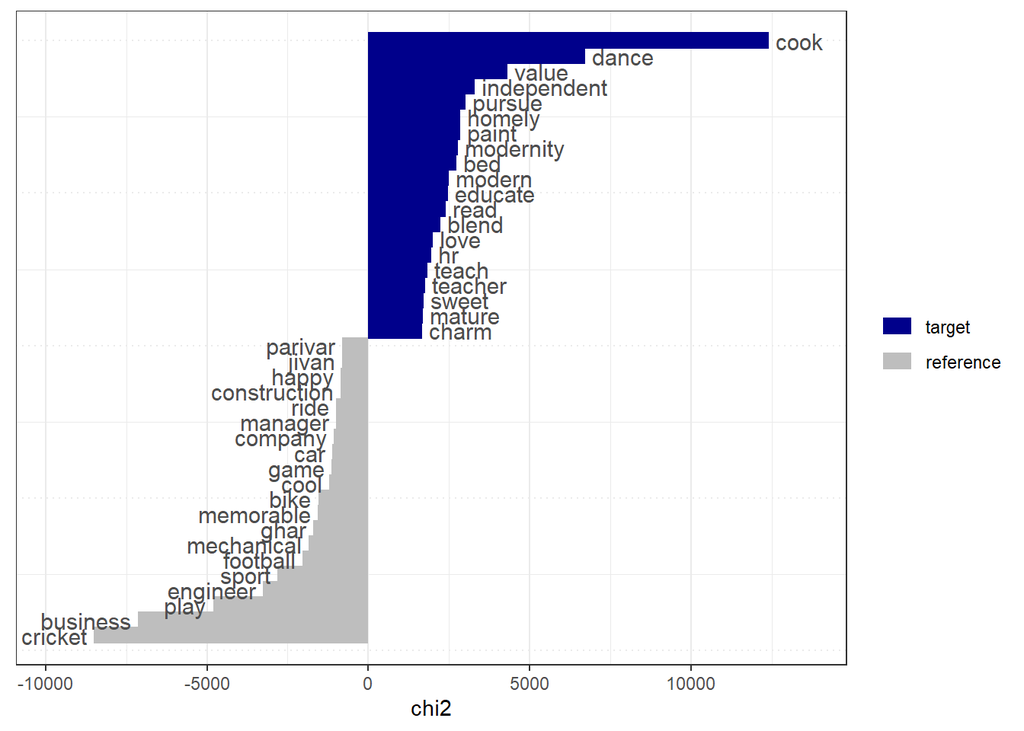

## Co-occurance of words in male and female profiles

We first create a matrix that gives the co-occurance of words occuring at least 1000 times in the data. We then plot the matrix into a network diagram, edges of which show the co-occurrences of the words.

### Female Network of Co-occurances

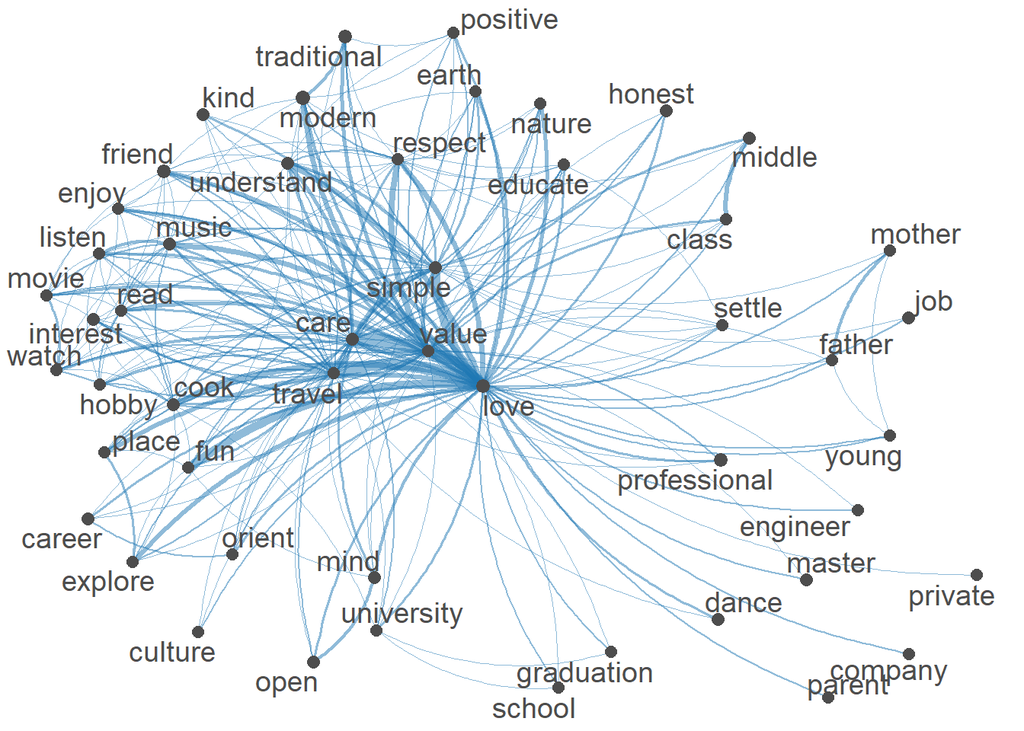

### Male Network of Co-occurances

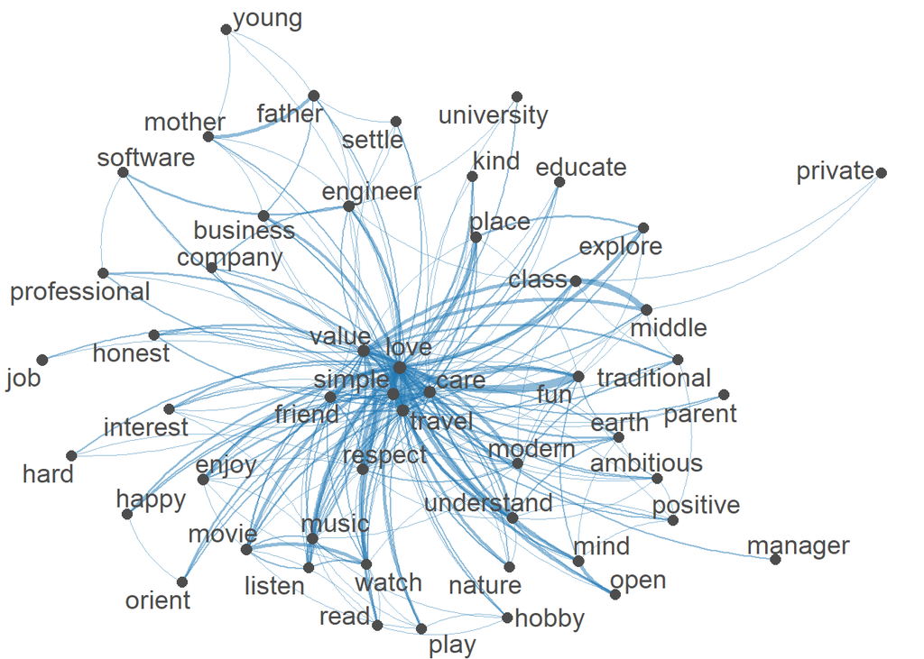

These tables and diagrams were generated out of only 1 variable (about the user) of the many (About 75) in the complete matrimonial dataset and hence there is a lot more to be seen.